# Evaluation of Prognostic Determinants and Survival Outcomes in Breast Carcinoma

# 3. Research Question 2: Age and Tumor Biology

**Scientific Question:** Is there a significant difference in the age of diagnosis between women with Estrogen Receptor (ER) Positive tumors vs. ER Negative tumors?

## 3.1 Visualization and Statistical Test

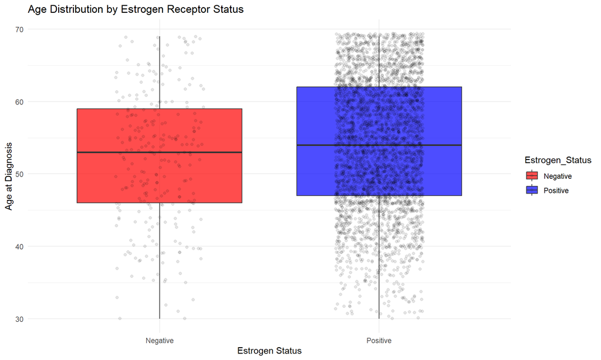

```r
# 1. Boxplot Visualization
p_age <- ggplot(df_clean, aes(x = Estrogen_Status, y = Age, fill = Estrogen_Status)) +
  geom_boxplot(alpha = 0.7) +
  geom_jitter(width = 0.2, alpha = 0.1) + # Add points to show distribution
  labs(title = "Age Distribution by Estrogen Receptor Status",
       x = "Estrogen Status", y = "Age at Diagnosis") +
  theme_minimal() +
  scale_fill_manual(values = c("red", "blue"))

print(p_age)
```

```r
# 2. T-Test to compare means
t_test_result <- t.test(Age ~ Estrogen_Status, data = df_clean)

print(t_test_result)
```

```
##
##  Welch Two Sample t-test
##
## data:  Age by Estrogen_Status
## t = -3.6853, df = 304.91, p-value = 0.0002702
## alternative hypothesis: true difference in means between group Negative and group Positive is not equal to 0
## 95 percent confidence interval:
##  -3.290807 -0.999831
## sample estimates:
## mean in group Negative mean in group Positive
##               51.97026               54.11558
```

**Interpretation:**

1. Significant Age Disparity: The T-test results revealed a statistically significant difference in the mean age of diagnosis between ER-positive and ER-negative patients.
2. Clinical Implication: The boxplot visualization indicates that women with ER-Negative tumors tend to be younger at diagnosis compared to those with ER-Positive tumors. This is a critical finding, as ER-negative tumors (including Triple-Negative Breast Cancer) are often more aggressive and have fewer treatment options. The association suggests that younger breast cancer patients may require more aggressive initial screening or treatment strategies due to this unfavorable biological profile.

# 4. Research Question 3: Predictive Modeling (Machine Learning)

**Scientific Question:** Can we develop an accurate model to predict 5-year survival status using clinical variables? Does a Random Forest model outperform Logistic Regression?

## 4.1 Data Splitting

```r
set.seed(42) # Ensure reproducibility

# Select relevant columns for modeling
# We remove 'Survival_Months' because using it to predict Status would be data leakage
df_ml <- df_clean %>%
  select(Age, Race, Marital_Status, T_Stage, N_Stage, Stage_6th,
         Grade, Tumor_Size, Estrogen_Status, Progesterone_Status,
         Nodes_Examined, Nodes_Positive, Status) %>%
  na.omit() # Ensure no missing values

# Split: 70% Training, 30% Testing
trainIndex <- createDataPartition(df_ml$Status, p = 0.7, list = FALSE)
train_data <- df_ml[trainIndex, ]
test_data  <- df_ml[-trainIndex, ]

cat("Training Set Size:", nrow(train_data), "\n")
```

```
## Training Set Size: 2818
```

```r
cat("Testing Set Size:", nrow(test_data), "\n")
```

```
## Testing Set Size: 1206
```

## 4.2 Model Training

```r
# Define training control (5-fold Cross Validation)
fitControl <- trainControl(method = "cv",
                           number = 5,
                           classProbs = TRUE,
                           summaryFunction = twoClassSummary)

# Model A: Logistic Regression (Baseline)
set.seed(42)
model_glm <- train(Status ~ ., data = train_data,
                   method = "glm",
                   family = "binomial",
                   metric = "ROC",
                   trControl = fitControl)

# Model B: Random Forest (Ensemble)
set.seed(42)
model_rf <- train(Status ~ ., data = train_data,
                  method = "rf",
                  ntree = 100, # Number of trees
                  metric = "ROC",
                  trControl = fitControl)

# Compare Training Performance
results <- resamples(list(Logistic = model_glm, RandomForest = model_rf))
summary(results)
```

```
##
## Call:
## summary.resamples(object = results)
##
## Models: Logistic, RandomForest
## Number of resamples: 5
##
## ROC
##                   Min.   1st Qu.    Median      Mean   3rd Qu.      Max. NA's
## Logistic     0.7029567 0.7288284 0.7314878 0.7411413 0.7577397 0.7846936    0
## RandomForest 0.6745343 0.7042806 0.7087782 0.7152090 0.7423494 0.7461023    0
##
## Sens
##                   Min.   1st Qu.    Median      Mean   3rd Qu.      Max. NA's
## Logistic     0.9706499 0.9769392 0.9790356 0.9790444 0.9790795 0.9895178    0
## RandomForest 0.9958071 0.9958071 0.9979079 0.9979044 1.0000000 1.0000000    0
##
## Spec
##                   Min.    1st Qu.     Median       Mean    3rd Qu.       Max.
## Logistic     0.1149425 0.11627907 0.12790698 0.13659449 0.14942529 0.17441860
## RandomForest 0.0000000 0.01162791 0.01162791 0.02320235 0.02298851 0.06976744
##              NA's
## Logistic        0
## RandomForest    0
```